# Lecture 8: Multivariate Analysis of Variance (MANOVA)

Zhaoxia Yu

Professor, Department of Statistics

2026-05-31

```r
knitr::opts_chunk$set(echo = TRUE)
library(tidyr) #the pipe (%>%) tool is extremely useful
library(MASS)
library(corrplot)#for visualizing the corr matrix of the iris data
library(car)
```

# Outline

- Introduction to MANOVA
- Review ANOVA (univariate)
- MANOVA test statistics
- Example

# Introduction

## Introduction to MANOVA

- So far we have learned
  - One-sample Hotelling’s $T^2$
  - Two-sample Hotelling’s $T^2$
- The next logical extension is to multiple samples, i.e., the multivariate version anova, or MANOVA
- Before that, we will review ANOVA for univariate data, and then we will see how to extend it to multivariate data

# Review of ANOVA (One-Way)

## Notations and Assumptions

- $g$ independent samples
  - $Y_{11}, \cdots Y_{1,n_1}\overset{iid}\sim N(\mu_1, \sigma^2)$
  - $Y_{21}, \cdots Y_{2,n_2}\overset{iid}\sim N(\mu_2, \sigma^2)$
  - $\cdots \cdots$
  - $Y_{g1}, \cdots Y_{g,n_g}\overset{iid}\sim N(\mu_g, \sigma^2)$
- Total sample size $n=n_1+\cdots + n_g=\sum_{i=1}^g n_i$
- Group means: $\bar{ Y}_{i.}$ for $i=1,\cdots, g$
- Grand/overall mean: $\bar{Y}_{..}$

## Partition the Sum of Squares of Total:

$$\begin{array}{lll} SSTO & = & \sum_{i=1}^{g}\sum_{j=1}^{n_i}\left(Y_{ij}-\bar{Y}_{..}\right)^2 = \sum_{i=1}^{g}\sum_{j=1}^{n_i}[(Y_{ij}-\bar{Y}_{i.})+(\bar{Y}_{i.}-\bar{Y}_{..})]^2 \\ & = &\sum_{i=1}^{g}\sum_{j=1}^{n_i}(Y_{ij}-\bar{Y}_{i.})^2+\sum_{i=1}^{g}n_i(\bar{Y}_{i.}-\bar{Y}_{..})^2 + \\
&&2 \sum_{i=1}^{g}\sum_{j=1}^{n_i}[(Y_{ij}-\bar{Y}_{i.})(\bar{Y}_{i.}-\bar{Y}_{..})]\\
&=&\sum_{i=1}^{g}\sum_{j=1}^{n_i}(Y_{ij}-\bar{Y}_{i.})^2+\sum_{i=1}^{g}n_i(\bar{Y}_{i.}-\bar{Y}_{..})^2 + \\
&&2 \sum_{i=1}^{g}[(\bar{Y}_{i.}-\bar{Y}_{..})\sum_{j=1}^{n_i}(Y_{ij}-\bar{Y}_{i.})]\\
&=&\sum_{i=1}^{g}\sum_{j=1}^{n_i}(Y_{ij}-\bar{Y}_{i.})^2+\sum_{i=1}^{g}n_i(\bar{Y}_{i.}-\bar{Y}_{..})^2 + 2 \sum_{i=1}^{g}[(\bar{Y}_{i.}-\bar{Y}_{..})\cdot 0]\\
&=&\underset{SSE}{\underbrace{\sum_{i=1}^{g}\sum_{j=1}^{n_i}[(Y_{ij}-\bar{Y}_{i.})^2}}+\underset{SSTR}{\underbrace{\sum_{i=1}^{g}n_i(\bar{Y}_{i.}-\bar{Y}_{..})^2}}
\end{array}$$

## SSE (also known as SSW)

- $SSTO=SSE+SSTR=SSW+SSB$:
- $SSE$ (i.e, $SSW$ ): sum of squares of **error**, also known as sum of squares **w**ithin (within groups).
  $$SSE=\sum_{i=1}^{g}\sum_{j=1}^{n_i}(Y_{ij}-\bar{Y}_{i.})^2=\sum_{i=1}^g (n_i-1)s_i^2$$
  where $s_i^2$ is the sample variance for the $i$th group.
- Recall that $E[s_i^2]=\sigma^2$. Therefore,
  $$E[SSE]=\sum_{i=1}^g (n_i-1)\sigma^2=(n-g)\sigma^2$$

## SSTR (also known as SSB)

- $SSTR$ is also known as $SSB$
  - B stands for **b**etween groups, or sum of squares **t**reatment
- The calculation of $E(SSTR)$ requires the following results

$$\begin{array}{lll}
E[\bar{Y}_{i.}^2]&=& Var[\bar{Y}_{i.}] + \mu_i^2=\frac{\sigma^2}{n_i} +\mu_i^2 \\
E[\bar{Y}_{..}^2]&=& Var[\bar{Y}_{..}] + \mu_{..}^2=\frac{\sigma^2}{n} +\mu_{..}^2\\
E[\bar{Y}_{i.}\bar{Y}_{..}] &=&\frac{1}{n}E[\bar{Y}_{i.}\sum_{j=1}^g n_j \bar Y_{j.}]= \frac{1}{n}E[\bar{Y}_{i.}(n_i\bar{Y}_{i.} + \sum_{j\ne i}^g n_j \bar Y_{j.})]\\
&=& \frac{n_i}{n}E[\bar{Y}_{i.}^2] + \mu_i \sum_{j\ne i} \frac{n_j}{n}\mu_j= \frac{1}{n}\sigma^2 + \frac{n_i}{n}\mu_i^2 + \mu_i \sum_{j\ne i} \frac{n_j}{n}\mu_j\\
&=& \frac{1}{n}\sigma^2+ \mu_i \bar \mu_{..}
\end{array}$$

$$\begin{array}{lll}
E[SSTR]
&=& \sum_{i=1}^g n_i E[(\bar{Y}_{i.}-\bar{Y}_{..})^2]\\
&=& \sum_{i=1}^g n_i E[\bar{Y}_{i.}^2+\bar{Y}_{..}^2 - 2\bar{Y}_{i.}\bar{Y}_{..} ]\\
&=& \sum_{i=1}^g n_i E[\bar{Y}_{i.}^2+\bar{Y}_{..}^2 - 2\bar{Y}_{i.}\bar{Y}_{..} ]\\
&=& \sum_{i=1}^g n_i (\frac{\sigma^2}{n_i} +\mu_i^2 + \frac{\sigma^2}{n} +\mu_{..}^2 -2[\frac{1}{n}\sigma^2+ \mu_i \bar \mu_{..}])\\
&=& (g-1)\sigma^2 + \sum_{i=1}^g n_i (\mu_i - \bar u_{..})^2
\end{array}$$
where $\bar \mu_{..}=\frac{1}{n} \sum_{i=1}^g n_i \mu_i$.

## Degrees of Freedom (DF)

- $SSE$ has $n-g$ degrees of freedom, because we have $n$ observations and we have estimated $g$ group means.
- $SSTR$ has $g-1$ degrees of freedom, because we have $g$ group means and we have estimated the overall mean $\bar Y_{..}$, which is a linear combination of the group means.
- $SSTO$ has $n-1$ degrees of freedom, because we have $n$ observations and we have estimated the overall mean $\bar Y_{..}$.
- Note that $n-1=(n-g)+(g-1)$, which is consistent with the partition of the sum of squares.

## Mean of Sum of Squares (MSE)

- $MSE=\frac{1}{n-g}SSE$, $E(MSE)=\sigma^2$
- $MSTR=\frac{1}{g-1}SSTR$, $E(MSTR)=\sigma^2 + \frac{1}{g-1}\sum_{i=1}^g n_i (\mu_i - \bar u_{..})^2$
- What is the ratio of the two expected mean sum of squares?

$$\frac{E(MSTR)}{E(MSE)}=\frac{\sigma^2 + \frac{1}{g-1}\sum_{i=1}^g n_i (\mu_i - \bar u_{..})^2}{\sigma^2} = 1 + \frac{\frac{1}{g-1}\sum_{i=1}^g n_i (\mu_i - \bar u_{..})^2}{\sigma^2}$$

- The ratio is a function of the between-group variability $\sum_{i=1}^g n_i (\mu_i - \bar u_{..})^2$ and the within-group variability $\sigma^2$. Large ratio suggests different means.
- The null hypothesis
  $$H_0\colon \mu_1 = \mu_2 = \dots = \mu_g$$
- The alternative hypothesis
  $$H_a\colon \mu_i \ne \mu_j \mbox{ for at least one pair of } (i,j)$$
- $\frac{E(MSTR)}{E(MSE)}\overset{H_0}=1$
- In practice we can calculate $\frac{MSTR}{MSE}$ and we expect large $\frac{MSTR}{MSE}$ to reject the null hypothesis.

## F-statistic

- The F-statistic is defined as

$$F=\frac{MSTR}{MSE}$$

- The null distribution

$$F=\frac{\frac{SSTR}{\sigma^2}/(g-1)}{\frac{SSE}{\sigma^2}/(n-g)}\overset{H_0}\sim F_{g-1, n-g}$$

- To derive the null distribution of $F$, we need to show that
  - $\frac{SSTR}{\sigma^2}\overset{H_0}\sim \chi_{g-1}^2$
  - $\frac{SSE}{\sigma^2}\sim \chi_{n-g}^2$
  - $SSTR$ and $SSE$ are independent

## ANOVA Table and Distributions

| Source | SS | MS | DF | F |
| --- | --- | --- | --- | --- |
| Tr | $SSTR=\sum_{i=1}^g n_i (\bar Y_{i.}-\bar Y_{..})^2$ | $MSTR=\frac{SSTR}{g-1}$ | $g-1$ | $F=\frac{MSTR}{MSE}$ |
| Error | $SSE=\sum_{i=1}^g\sum_{j=1}^{n_i} (Y_{ij}-\bar Y_{i.})^2$ | $MSE=\frac{SSE}{n-g}$ | $n-g$ |  |
| **Total** | $SSTO=\sum_{i=1}^g\sum_{j=1}^{n_i} (Y_{ij}-\bar Y_{..})^2$ |  | $n-1$ |  |

# MANOVA

## Methods for MANOVA

- Compared to one-sample or two-sample multivariate analysis, there are many choices for comparing multiple samples for multivariate data
- We will cover the following methods:
  - Wilks’ Lambda
  - Pillai’s Trace
  - Hotelling-Lawley Trace
  - Roy’s Largest Root

# MANOVA: T = B + W

## Notations and Assumptions

- $g$ **independent** random samples
  - $\mathbf Y_{11}, \cdots \mathbf Y_{1,n_1}\overset{iid}\sim N(\boldsymbol \mu_1, \boldsymbol\Sigma)$
  - $\mathbf Y_{21}, \cdots \mathbf Y_{2,n_2}\overset{iid}\sim N(\boldsymbol \mu_2, \boldsymbol\Sigma)$
  - $\cdots \cdots$
  - $\mathbf Y_{g1}, \cdots \mathbf Y_{g,n_g}\overset{iid}\sim N(\boldsymbol \mu_g, \boldsymbol\Sigma)$
- $n_i$: the number of observations in group $i$
- The $i$th random sample is from $N(\boldsymbol \mu_i, \boldsymbol\Sigma)$
- Each $\mathbf Y_{ij}\in \mathbb R^p$, i.e,
  $$\mathbf Y_{ij}=\left(\begin{array}{c}Y_{ij1}\\Y_{ij2}\\\vdots\\Y_{ijp}\end{array}\right)$$
- The null hypothesis vs the alternative:

$$\begin{align}
H_0\colon & \boldsymbol \mu_1 = \boldsymbol \mu_2 = \dots = \boldsymbol \mu_g\\
H_1\colon & \boldsymbol \mu_i \ne \boldsymbol \mu_j \mbox{ for at least one pair of } (i,j)
\end{align}$$

## The Total Covariance Matrix

- The total covariance matrix is the covariance matrix if the group information is ignored. If we pool all the $n=n_1+\cdots+n_g=\sum_{i=1}^g n_g$ observations together, what is the covariance matrix?

$$\begin{array}{lll}
\mathbf{T}
& = & \sum_{i=1}^{g}\sum_{j=1}^{n_i}(\mathbf Y_{ij}- \bar {\mathbf Y}_{..})(\mathbf Y_{ij}-\bar {\mathbf Y}_{..})' \\
& = & \sum_{i=1}^{g}\sum_{j=1}^{n_i}\{(\mathbf Y_{ij}-\bar {\mathbf{ Y}}_i)+(\bar{ \mathbf Y}_i-\bar{\mathbf Y}_{..})\}\{(\mathbf Y_{ij}-\bar{\mathbf Y}_i)+(\bar{\mathbf Y}_i-\bar{\mathbf Y}_{..})\}'
\\ & = & \underset{W}{\underbrace{\sum_{i=1}^{g}\sum_{j=1}^{n_i}(\mathbf Y_{ij}-\bar{\mathbf Y}_{i.})(\mathbf Y_{ij}-\bar{ \mathbf Y}_{i.})'}}+\underset{B}{\underbrace{\sum_{i=1}^{g}n_i(\bar{ \mathbf Y}_{i.}-\bar{\mathbf Y}_{..})(\bar{\mathbf Y}_{i.}-\bar{\mathbf Y}_{..})'}} + 0
\end{array}$$

## The Within-Group Sample Covariance Matrix

- In the definition of the total covariance matrix, we compare each observation to the grand mean vector
- In within-group covariance matrix, we compare each observation to its group mean
  $$\mathbf W=\sum_{i=1}^{g}\sum_{j=1}^{n_i}(\mathbf Y_{ij}-\bar{\mathbf Y}_{i.})(\mathbf Y_{ij}-\bar{\mathbf Y}_{i.})'$$
- Let $\mathbf W_i=\sum_{j=1}^{n_i}(\mathbf Y_{ij}-\bar{\mathbf Y}_{i.})(\mathbf Y_{ij}-\bar{\mathbf Y}_{i.})'$. We can show that
  $$\mathbf W_1, \cdots, \mathbf W_g \overset{independent}\sim Wishart_p(n_i-1, \boldsymbol \Sigma)$$
- Recall that the sum of independently distributed chi-squared distributed random variables also follows a chi-squared distribution. Similarly,
  $$\mathbf{ W=\sum_{i=1}^g W_i \sim Wishart_p(n-g, \boldsymbol \Sigma)}$$

## The Between-Group Sample Covariance Matrix

- $\mathbf B$ captures the difference in mean vectors between groups

$$\mathbf B=\sum_{i=1}^{g}n_i(\bar{\mathbf Y}_{i.}-\bar{\mathbf Y}_{..})(\bar{\mathbf Y}_{i.}-\bar{\mathbf Y}_{..})'$$

- When the null hypothesis is true, $\mathbf B$ follows a Wishart distribution
  $$\mathbf B\overset{H_0}\sim Wishart_p(g-1, \boldsymbol \Sigma)$$

## Outline of Proof

- Let $\mathbf Y_{n\times p}$ denote the data matrix
- Let $\mathbf X_{n\times g}$ denote the design matrix, which consists of dummy variables of the group membership. We also define $\mathbf {P_{n\times n}=X(X^TX)^{-1}X^T}$. Then

$$\mathbf X=
\begin{pmatrix}
\mathbf 1_{n_1} & \mathbf 0_{n_1} & \cdots & \mathbf 0_{n_1}\\
\mathbf 0_{n_2} & \mathbf 1_{n_2} & \cdots & \mathbf 0_{n_2}\\
\cdots & \cdots & \cdots & \cdots \\
\mathbf 0_{n_g} & \mathbf 0_{n_g} & \cdots & \mathbf 1_{n_g}
\end{pmatrix},
\mathbf P=
\begin{pmatrix}
\frac{1}{n_1}\mathbf 1_{n_1}\mathbf 1_{n_1}^T & \mathbf 0 & \cdots & \mathbf 0\\
\mathbf 0 & \frac{1}{n_2}\mathbf 1_{n_2}\mathbf 1_{n_2}^T& \cdots & \mathbf 0\\
\cdots & \cdots & \cdots & \cdots \\
\mathbf 0 & \mathbf 0 & \cdots & \frac{1}{n_g}\mathbf 1_{n_g}\mathbf 1_{n_g}^T
\end{pmatrix}$$
It can be shown that
$$\mathbf W = \mathbf Y^T (\mathbf I - \mathbf P)\mathbf Y \mbox{ , }
\mathbf B = \mathbf Y^T (\mathbf P-\frac{1}{n}\mathbf 1_n \mathbf 1_n^T)\mathbf Y$$

- It is not difficult to verify that $\mathbf P$, $\mathbf I - \mathbf P$, and $\mathbf P -\frac{1}{n}\mathbf 1_n \mathbf 1_n^T$ are all projection matrices. For a projection matrix, its rank equals its trace. Thus, it is not difficult to show that
  $$rank(\mathbf P)=g, rank(\mathbf I - \mathbf P)=n-g, rank(\mathbf P -\frac{1}{n}\mathbf 1_n \mathbf 1_n^T)=g-1$$
- In Lecture 06 we showed that $(n-1)\mathbf S \sim Wishart_p(n-1, \boldsymbol \Sigma)$. Use similar methods, we can show that
  $$\begin{aligned}
  \mathbf W &\sim Wishart_p(n-g, \boldsymbol \Sigma) \mbox{ , }\mathbf B \overset{H_0}\sim Wishart_p(g-1, \boldsymbol \Sigma)\\
  \mathbf W & \perp \mathbf B
  \end{aligned}$$

## MANOVA Table

- We can also construct a table

Table 1: MANOVA Summary Table

| Source | Sample Cov | DF |
| --- | --- | --- |
| Treatment | $\mathbf{B}=\sum_{i=1}^{g}n_i(\bar{\mathbf{Y}}_{i.}-\bar{\mathbf{Y}}_{..})(\bar{\mathbf{Y}}_{i.}-\bar{\mathbf{Y}}_{..})'$ | $g-1$ |
| Error | $\mathbf{W}=\sum_{i=1}^{g}\sum_{j=1}^{n_i}(\mathbf{Y}_{ij}-\bar{\mathbf{Y}}_{i.})(\mathbf{Y}_{ij}-\bar{\mathbf{Y}}_{i.})'$ | $n-g$ |
| Total | $\mathbf{T}=\sum_{i=1}^{g}\sum_{j=1}^{n_i}(\mathbf{Y}_{ij}- \bar{\mathbf{Y}}_{..})(\mathbf{Y}_{ij}-\bar{\mathbf{Y}}_{..})'$ |  |

## Iris Data: $B$ and $W$

```r
#rearrange the data such as the response matrix is
#an n-by-p matrix
Y=cbind(SepalL=c(iris3[,1,1],iris3[,1,2],iris3[,1,3]),
SepalW=c(iris3[,2,1],iris3[,2,2],iris3[,2,3]),
PetalL=c(iris3[,3,1],iris3[,3,2],iris3[,3,3]),
PetalW=c(iris3[,4,1],iris3[,4,2],iris3[,4,3]))
#for unknown reasons, data.frame won't work but cbind works
#alternatively, we can use the following way to define y
#Y=aperm(iris3,c(1,3,2));dim(y)=c(150,4)

#define the covariate variable X, which is vector of labels
iris.type=rep(c("Setosa","Versicolor","Virginica"),each=50)
T=(150-1)*cov(Y)
W=(50-1)*cov(iris3[,,1]) +(50-1)*cov(iris3[,,2])+(50-1)*cov(iris3[,,3])
B=T-W
```

## Iris Data: $B$ and $W$

```r
B
```

```
          SepalL    SepalW   PetalL    PetalW
SepalL  63.21213 -19.95267 165.2484  71.27933
SepalW -19.95267  11.34493 -57.2396 -22.93267
PetalL 165.24840 -57.23960 437.1028 186.77400
PetalW  71.27933 -22.93267 186.7740  80.41333
```

```r
W
```

```
         Sepal L. Sepal W. Petal L. Petal W.
Sepal L.  38.9562  13.6300  24.6246   5.6450
Sepal W.  13.6300  16.9620   8.1208   4.8084
Petal L.  24.6246   8.1208  27.2226   6.2718
Petal W.   5.6450   4.8084   6.2718   6.1566
```

```r
B+W
```

```
           SepalL     SepalW   PetalL    PetalW
SepalL 102.168333  -6.322667 189.8730  76.92433
SepalW  -6.322667  28.306933 -49.1188 -18.12427
PetalL 189.873000 -49.118800 464.3254 193.04580
PetalW  76.924333 -18.124267 193.0458  86.56993
```

# MANOVA Test

## Test Statistics

- In one-way ANOVA, we understand that $SSB$ should be large relative to $SSW$ when the null hypothesis is not true
- In the multivariate version, we also expect that $\mathbf B$ should be large relative to $\mathbf W$ when the null hypothesis is not true
- However, $\mathbf B$ and $\mathbf W$ are matrices. How to define “large”?

## MANOVA in R

```
summary.manova {stats}  R Documentation
Summary Method for Multivariate Analysis of Variance
Description
A summary method for class "manova".

Usage
## S3 method for class 'manova'
summary(object,
        test = c("Pillai", "Wilks", "Hotelling-Lawley", "Roy"),
        intercept = FALSE, tol = 1e-7, ...)
```

## Method 1: Pallai Trace

$$V = trace(\mathbf{\mathbf B(\mathbf B+\mathbf W)^{-1}})=trace(\mathbf B \mathbf T^{-1})$$

## Method 2: Wilk’s Lambda

- Wilk’s Lambda distribution Let $\mathbf A\sim Wishart_p(m_1, \mathbf I)$ and $\mathbf B\sim Wishart_p(m_2, \mathbf I)$ be independent with $m_1>p$. We say
  $$\Lambda=\dfrac{|\mathbf{A}|}{|\mathbf{A+B}|}\sim \Lambda (p, m_1, m_2)$$
- Test Statistic
  $$\Lambda^* = \dfrac{|\mathbf{W}|}{|\mathbf{B+W}|}=\dfrac{|\mathbf{W}|}{|\mathbf{T}|}=\dfrac{|\mathbf{\boldsymbol \Sigma^{-1/2} W\boldsymbol \Sigma^{-1/2} }|}{|\mathbf{\boldsymbol \Sigma^{-1/2} (B+W)\boldsymbol \Sigma^{-1/2} }|}$$
- By the definition of Wilk’s Lambda distribution,
  $$\Lambda^* \overset{H_0}\sim \Lambda (p, n-g, g-1)$$

## Method 3: Lawley-Hotelling Trace

$$T^2 = trace(\mathbf{BW}^{-1})$$

## Method 4: Roy’s Largest Root

- Two equivalent test statistics have been used
  $$\begin{aligned}
  \lambda_{max}(\mathbf B\mathbf W^{-1})\\
  \lambda_{max}(\mathbf B\mathbf {(B+W)}^{-1})
  \end{aligned}$$

## Test Statistics and the Eigenvalues

- One interesting observation is that all the test statistics can be expressed in terms of eigenvalues of $\mathbf B \mathbf W^{-1}$. Let $\lambda_1, \cdots, \lambda_p$ denote the eigenvalues, from the largest to the smallest. We have
- Pillai trace
  $$tr(\mathbf B (\mathbf B + \mathbf W)^{-1})=\sum_{i=1}^{min(p, g-1)}\frac{\lambda_i}{1+\lambda_i}$$
- Wilk’s Lambda
  $$\Lambda^*= \prod_{i=1}^{min(p, g-1)}\frac{1}{1+\lambda_i}$$

## Test Statistics and the Eigenvalues of $\mathbf B \mathbf W^{-1}$

- Lawley-Hotelling trace
  $$trace(\mathbf B \mathbf W^{-1}) = \sum_{i=1}^{min(p, g-1)}\lambda_i$$
- Roy’s largest root
  $$\begin{aligned}
  \lambda_{max}(\mathbf B\mathbf W^{-1}) = \lambda_1\\
  \lambda_{max}(\mathbf B\mathbf {(B+W)}^{-1})= \frac{\lambda_1}{1+\lambda_1}
  \end{aligned}$$

## Proof

- If you are curious about how to prove these results, I provide an example.
  $$\begin{aligned}
  (\Lambda ^{*})^{-1} &= \dfrac{|\mathbf{B+W}|}{|\mathbf{W}|} = |\mathbf{I +W^{-1} B}|\\
  &= \prod_{i=1}^p [\mbox{the ith eigenvalue of } \mathbf{I +W^{-1} B}]\\
  &= \prod_{i=1}^p [1 + \mbox{the ith eigenvalue of } \mathbf{W^{-1} B}]\\
  &= \prod_{i=1}^p (1 + \lambda_i)\overset{1}=\prod_{i=1}^{min(p,g-1)} (1 + \lambda_i)
  \end{aligned}$$
  As a result, $\Lambda ^{*}=\prod_{i=1}^p \frac{1}{1 + \lambda_i}$

## Proof (continued)

- The last step implies that $rank(\mathbf W^{-1}\mathbf B)=min(p, g-1)$
- Why is it true?
  - First, $rank(\mathbf W^{-1}\mathbf B)=rank(\mathbf B)$
  - Second, because $\mathbf B\overset{H_0}\sim Wishart_p(g-1, \boldsymbol \Sigma)$, there exists $\mathbf Y_{(g-1)\times p}$ such that
    $$\mathbf B = \mathbf Y^T \mathbf Y \mbox{ , }$$
    and $\mathbf Y$ is a random sample of size $g-1$ from $N(\mathbf 0, \boldsymbol \Sigma)$. The rank of $\mathbf Y$ is $rank(\mathbf Y)=min(p, g-1)$.
  - Third, $rank(\mathbf B)= rank(\mathbf Y^T\mathbf Y)=rank(\mathbf Y)=min(p, g-1)$.

## Example - Iris Data

```r
mycolors=rainbow(12)[9:1]
image(t(iris[150:1, 1:4]),col = mycolors, xaxt="n", yaxt="n")
```

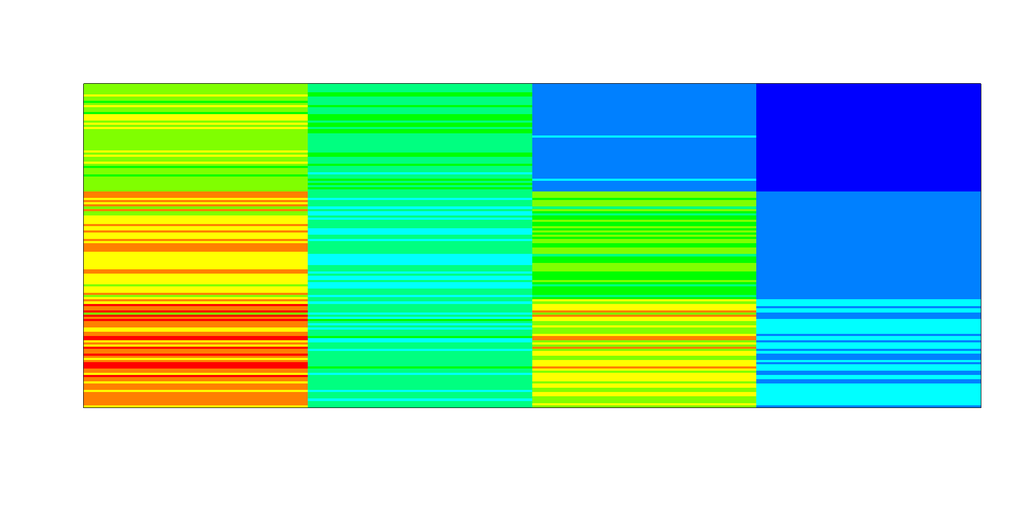

# Example

## Iris Data: Univariate One-way ANOVA: Data Formatting

```r
#rearrange the data in the (X,Y) format
y=c(iris3[,1,1], iris3[,1,2], iris3[,1,3])
#alternatively, you may use:
#y=aperm(iris3[,1,], c(1,2)); dim(y)=c(150,1)

#define the covariate variable X,
#which is vector of labels
iris.type=rep(c("Setosa","Versicolor","Virginica"),each=50)
```

## Iris Data: Univariate One-way ANOVA: Exploratory

```r
#visual checking
par(mfrow=c(2,2))
#box plot
boxplot(y~iris.type, main="SepalL")
#alternatively, you may use: boxplot(iris3[,1,],
#main="SepalL")

#qq plots
qqnorm(iris3[,1,1], main="Q-Q Plot: Setosa");
qqline(iris3[,1,1])
qqnorm(iris3[,1,2], main="Q-Q Plot: Versicolor");
qqline(iris3[,1,2])
qqnorm(iris3[,1,3], main="Q-Q Plot: Virginica");
qqline(iris3[,1,3])
```

## Iris Data: Univariate One-way ANOVA: Exploratory

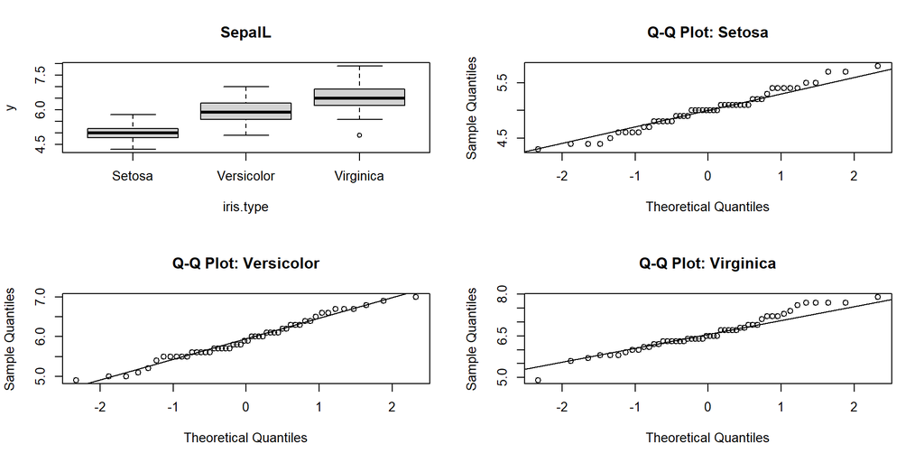

## Iris Data: Univariate One-way ANOVA: Analysis

```r
obj.aov=aov(y~iris.type)
summary(obj.aov)
```

```
             Df Sum Sq Mean Sq F value Pr(>F)
iris.type     2  63.21  31.606   119.3 <2e-16 ***
Residuals   147  38.96   0.265
---
Signif. codes:  0 '***' 0.001 '**' 0.01 '*' 0.05 '.' 0.1 ' ' 1
```

## Iris Data: MANOVA: Data Formatting

```r
#rearrange the data such as the response matrix is
#an n-by-p matrix
Y=cbind(SepalL=c(iris3[,1,1],iris3[,1,2],iris3[,1,3]),
SepalW=c(iris3[,2,1],iris3[,2,2],iris3[,2,3]),
PetalL=c(iris3[,3,1],iris3[,3,2],iris3[,3,3]),
PetalW=c(iris3[,4,1],iris3[,4,2],iris3[,4,3]))
#for unknown reasons, data.frame won't work but cbind works
#alternatively, we can use the following way to define y
#Y=aperm(iris3,c(1,3,2));dim(y)=c(150,4)

#define the covariate variable X, which is vector of labels
iris.type=rep(c("Setosa","Versicolor","Virginica"),each=50)
```

## Iris Data: MANOVA: Exploratory

```r
#visual investigation
par(mfrow=c(2,2))
boxplot(iris3[,1,],main="SepalL")
boxplot(iris3[,2,],main="SepalW")
boxplot(iris3[,3,],main="PetalL")
boxplot(iris3[,4,],main="PetalW")
```

## Iris Data: MANOVA: Exploratory

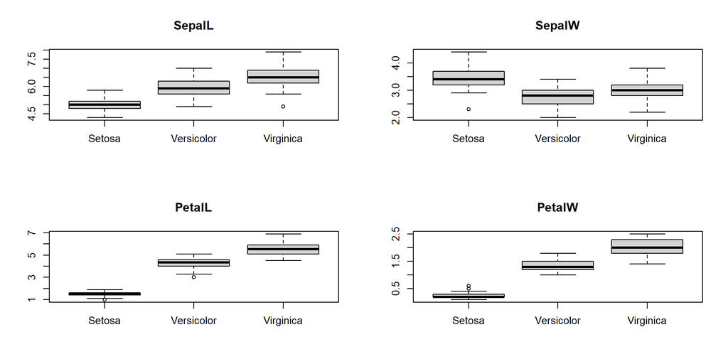

## Conducting MANOVA “Manually”

```r
T=(150-1)*cov(Y)
W=(50-1)*cov(iris3[,,1]) +(50-1)*cov(iris3[,,2])+(50-1)*cov(iris3[,,3])
B=T-W
Lambda=prod(1/(1+ eigen(B%*%solve(W))$values))
(150-3-2)/3*(1-sqrt(Lambda))/sqrt(Lambda)
```

```
[1] 267.3711
```

```r
# Using relationship between Wilk's lambda and F-distribution
# (see wikipedia about "Wilks's lambda distribution")
1-pf((150-3-2)/3*(1-sqrt(Lambda))/sqrt(Lambda), 2*3, 150-3-2)
```

```
[1] 0
```

## Conducting MANOVA using “manova” in R

```r
obj=manova(Y~iris.type)
obj
```

```
Call:
   manova(Y ~ iris.type)

Terms:
                iris.type Residuals
SepalL            63.2121   38.9562
SepalW            11.3449   16.9620
PetalL           437.1028   27.2226
PetalW            80.4133    6.1566
Deg. of Freedom         2       147

Residual standard errors: 0.5147894 0.3396877 0.4303345 0.20465
Estimated effects may be unbalanced
```

## Conducting MANOVA using “manova” in R

```r
summary(obj, test="Pillai")
```

```
           Df Pillai approx F num Df den Df    Pr(>F)
iris.type   2 1.1919   53.466      8    290 < 2.2e-16 ***
Residuals 147
---
Signif. codes:  0 '***' 0.001 '**' 0.01 '*' 0.05 '.' 0.1 ' ' 1
```

```r
summary(obj, test="Wilks")
```

```
           Df    Wilks approx F num Df den Df    Pr(>F)
iris.type   2 0.023439   199.15      8    288 < 2.2e-16 ***
Residuals 147
---
Signif. codes:  0 '***' 0.001 '**' 0.01 '*' 0.05 '.' 0.1 ' ' 1
```

## Conducting MANOVA using “manova” in R

```r
summary(obj, test="Hotelling-Lawley")
```

```
           Df Hotelling-Lawley approx F num Df den Df    Pr(>F)
iris.type   2           32.477   580.53      8    286 < 2.2e-16 ***
Residuals 147
---
Signif. codes:  0 '***' 0.001 '**' 0.01 '*' 0.05 '.' 0.1 ' ' 1
```

```r
summary(obj, test="Roy")
```

```
           Df    Roy approx F num Df den Df    Pr(>F)
iris.type   2 32.192     1167      4    145 < 2.2e-16 ***
Residuals 147
---
Signif. codes:  0 '***' 0.001 '**' 0.01 '*' 0.05 '.' 0.1 ' ' 1
```

## Too Many Choices?

- Due to the nature of multivariate analysis, we have seen many choices for conducting one-way MANOVA
- Do they work equally well?
- Does their performance depend on the true distribution?
- You will be asked to compare the methods in your midterm project